# Hierarchical Linear Model

ChatGPT 4o

2025-01-21

## 1 起源

分层线性模型（Hierarchical Linear Model, HLM），又称多层线性模型（Multilevel Linear Model），是一种用于分析嵌套数据的统计方法。HLM最早在20世纪80年代由Raudenbush和Bryk等统计学家提出，用于解决数据中存在的多层结构问题，例如学生嵌套于班级、班级嵌套于学校的情况。传统的线性回归假设数据独立同分布（i.i.d），但在嵌套数据中，这一假设通常不成立，因此需要HLM来分析这种结构化的层次关系。

## 2 原理

分层线性模型的核心原理是通过在不同层次上构建回归方程来描述嵌套数据的关系。HLM模型通常包括两个或多个层次：

- **一级模型（Level-1 Model）**：描述最底层单位（如学生）的变异，建模自变量对因变量的直接影响。
- **二级模型（Level-2 Model）**：描述更高层单位（如班级）的变异，用于解释一级模型参数的差异。

数学模型形式为：

一级模型：
$$Y_{ij} = \beta_{0j} + \beta_{1j} X_{ij} + e_{ij}$$

二级模型：
$$\beta_{0j} = \gamma_{00} + u_{0j}$$
$$\beta_{1j} = \gamma_{10} + u_{1j}$$

通过组合一级和二级模型，可以估计不同层次上的效应，同时考虑到不同层次间的相关性和差异。

## 3 适用范围

分层线性模型适用于以下情况：

- **嵌套数据**：当数据具有明显的嵌套结构（如学生嵌套在班级中，员工嵌套在部门中）时，可以使用HLM。
- **多层因素的影响**：当多个层次因素可能同时影响因变量时，HLM能够有效地分离不同层次的变异来源。
- **群体间的差异分析**：当需要考察群体间的差异（如学校间、地区间）对个体的影响时，HLM是一个理想的选择。

## 4 应用情境

分层线性模型在多个领域中都有广泛的应用，例如：

- **教育学**：分析学生成绩的影响因素，将学生嵌套在班级、班级嵌套在学校中，以评估学校和班级对学生表现的影响。
- **社会学**：研究个体行为受到的家庭、社区和地区等多层次影响，如健康行为受社区环境的影响。
- **医学研究**：分析患者嵌套在医院中的数据，研究医院因素对治疗效果的影响。
- **组织行为学**：分析员工表现受团队和公司层次影响的情况，评估团队文化或公司政策对员工绩效的影响。

## 5 优缺点

### 优点

- **考虑嵌套结构**：HLM能够有效处理嵌套数据的相关性，避免忽略嵌套关系可能导致的偏误。
- **灵活性强**：HLM可以包含多个层次，灵活地建模不同层次变量之间的关系。
- **提高模型精度**：HLM通过分离个体间和群体间的变异，能够提高对因变量解释的精度。

### 缺点

- **对样本量要求高**：HLM通常需要较大的样本量，尤其是在高层级单位较少的情况下，模型估计可能不稳定。
- **模型复杂，解释困难**：由于HLM涉及多层次效应，模型的解释和结果的可视化可能较为复杂。
- **对数据的要求高**：HLM要求数据在不同层次上有足够的变异，且需要较好地满足正态性和线性关系假设。

## 6 在R中的实现及结果解释

在R中，可以使用`lme4`包中的`lmer()`函数进行分层线性模型的分析。以下是一个实现HLM的示例：

```r
# 加载必要的包
library(lme4)
```

```r
library(ggplot2)

# 示例数据：生成假设数据
set.seed(123)
data <- data.frame(
  student_id = rep(1:100, each = 3),
  class_id = rep(1:10, each = 30),
  score = rnorm(300, mean = 70, sd = 10),
  study_hours = rnorm(300, mean = 5, sd = 2),
  class_effect = rep(rnorm(10, mean = 0, sd = 5), each = 30)
)

data$score <- data$score + data$class_effect  # 添加班级效应以增加变异性

# 进行分层线性模型分析
model <- lmer(score ~ study_hours + (1 | class_id), data = data)

# 输出模型结果
summary(model)
```

```
## Linear mixed model fit by REML ['lmerMod']
## Formula: score ~ study_hours + (1 | class_id)
##    Data: data
##
## REML criterion at convergence: 2215.8
##
## Scaled residuals:
##     Min      1Q  Median      3Q     Max
## -2.5303 -0.6242 -0.1593  0.5932  3.2483
##
## Random effects:
##  Groups   Name        Variance Std.Dev.
##  class_id (Intercept) 15.41    3.926
##  Residual             90.03    9.488
## Number of obs: 300, groups:  class_id, 10
##
## Fixed effects:
##             Estimate Std. Error t value
## (Intercept)  70.0954     1.9537   35.88
## study_hours  -0.2633     0.2801   -0.94
##
## Correlation of Fixed Effects:
##             (Intr)
## study_hours -0.720
```

```r
str(model)
```

[output not shown]

[output cut: 74 more lines]

[output not shown]

### 结果解释

- **固定效应**：模型的固定效应部分表示自变量（如`study_hours`）对因变量（如`score`）的影响强度。固定效应系数的估计值和显著性检验结果反映了各自变量的影响力。
- **随机效应**：随机效应部分表示不同群体（如`class_id`）之间的变异。可以通过随机效应的方差成分评估不同层次对因变量的影响大小。
- **模型拟合度**：通过AIC、BIC等指标可以比较不同模型的拟合效果，选择最优模型。

### 结果的可视化

可以使用`ggplot2`包对HLM的结果进行可视化，以展示不同班级对学生成绩的影响。

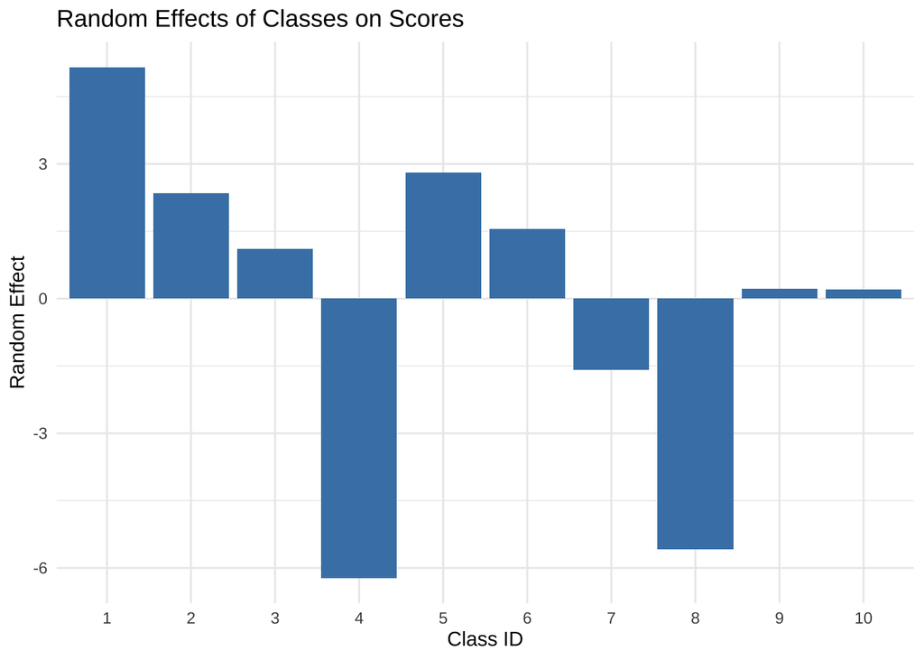

```r
# 绘制班级随机效应的可视化
random_effects <- ranef(model)$class_id
random_effects_df <- data.frame(class_id = factor(rownames(random_effects), levels = as.character(1:10)), effect = random_effects[, 1])

# 绘制班级随机效应条形图
ggplot(random_effects_df, aes(x = class_id, y = effect)) +
  geom_bar(stat = "identity", fill = "steelblue") +
  labs(title = "Random Effects of Classes on Scores", x = "Class ID", y = "Random Effect") +
  theme_minimal()
```

上述代码将生成班级随机效应的条形图，用于展示不同班级对学生成绩的影响大小，便于理解群体间的变异来源。

## 7 小结

- 分层线性模型是一种用于分析嵌套数据的统计方法，能够同时考虑个体和群体层次的影响。
- 适用于具有嵌套结构的数据，如教育、社会学和医学研究中，能够揭示多个层次对因变量的共同影响。
- 具有处理嵌套数据、提高模型精度的优点，但对样本量和数据要求较高，且模型解释较为复杂。
- 可以通过R中的`lmer()`函数实现HLM，并结合可视化工具直观展示随机效应结果。
- 在教育学、社会学、医学和组织行为学等领域，HLM是一种重要的工具，用于理解多层次对个体的共同影响。